# SPHA training

Julian Flowers

2024-03-31

## Brief

1. Working with Simon to design training materials for two the following topics:
   1. Acting on data (Principles) & Open-Source data
   2. Data visualisation and Insight generation
2. We also would like your support with the Proof of Concept (see attached), for this we envisage you supporting us with reviewing the dataset and advising on the best methodology approaches to take with regards to conducting data analysis and reporting.

**Next steps:**

1. Please can you liaise with Simon and come up with the number of days for the training work?
2. With regards to the PHOF work we estimate this will take about 5 days of your time in total – if this is more, we can review once the project has kicked off and increase the days.
3. I will be in touch separately to discuss contracting arrangements with IQVIA.

## Open data

https://www.go-fair.org/fair-principles/

**F**indable

- Metadata is better data
  - Rich
  - Indexed
  - Registered
  - Built on open metadata standards
  - Searchable, discoverable, platform independent
- FAIRification

**A**ccessible

- Free and open comms protocol
- Open authentication
- Metadata persistence

**I**nteroperable

- Open knowledge representation standards
- Open vocabularies

**R**eusable

- Releases
- Licensing
- Provenance

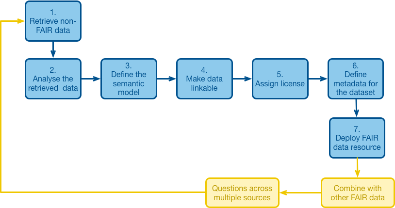

## Data infrastructure

APIs

JSON

Database architecture

Fingertips data model as an example

## Performance

Direction

Desirability

Magnitude

Always comparative

- Baseline
- Target
- General trend
- Defined standards / expectation
- Expected values (models)
- Outlier or out of control

## **Actionable data**

SPC - statistical

Limits

How are we doing?

Timeliness

Forecasts

Models

Causal pathways

- Do we have actions we can take?
  - Review
  - Policy
  - Practice
  - Incentives / disincentives
  - Services
  - Engagement
    - Professionals
    - Public
  - Timescales
    - When can we do it?
    - How long will it take to show effect?
    - How will we know if its working
  - Trends
  - Time series analyses and models

PHOF

Highly multivariate

Population groups x indicators

Multivatariate analyses (unsupervised) => clustering; ordination

Ordination

- PCA
- UMAP / tSNE
- CCA / ICA
- NMDS
- FA

## Population health strategies

Population vs targetted

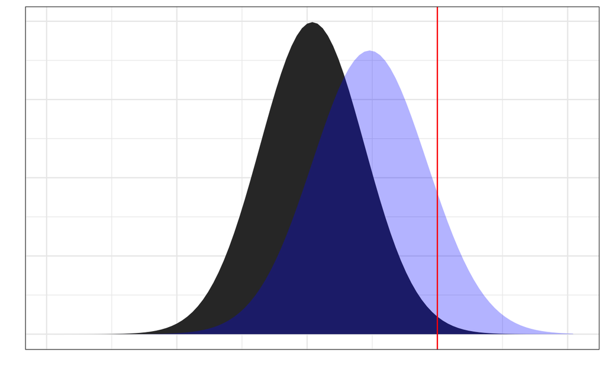